# Lista 1 Séries

Davi Wentrick Feijó

2024-03-19

#### 1.1 Use software to produce the time series plot shown in Exhibit 1.2, on page 2. The data are in the file named `larain`.

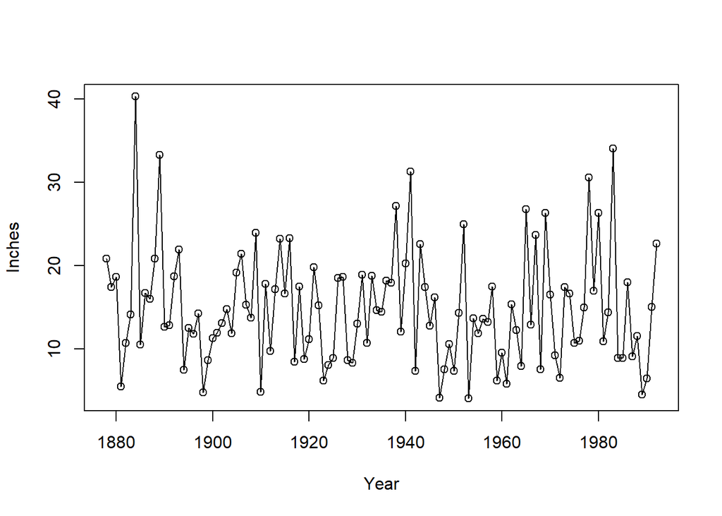

```r
plot(larain,ylab='Inches',xlab='Year',type='o')
```

#### 1.2 Produce the time series plot displayed in Exhibit 1.3, on page 3. The data file is named color.

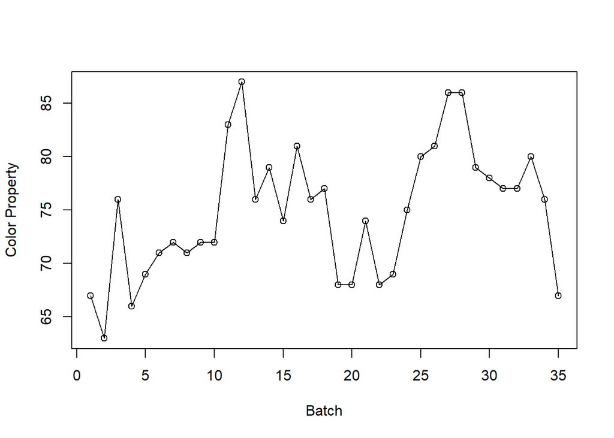

```r
plot(color,ylab='Color Property',xlab='Batch',type='o')
```

#### 1.3 Simulate a completely random process of length 48 with independent, normal values. Plot the time series plot. Does it look “random”? Repeat this exercise several times with a new simulation each time.

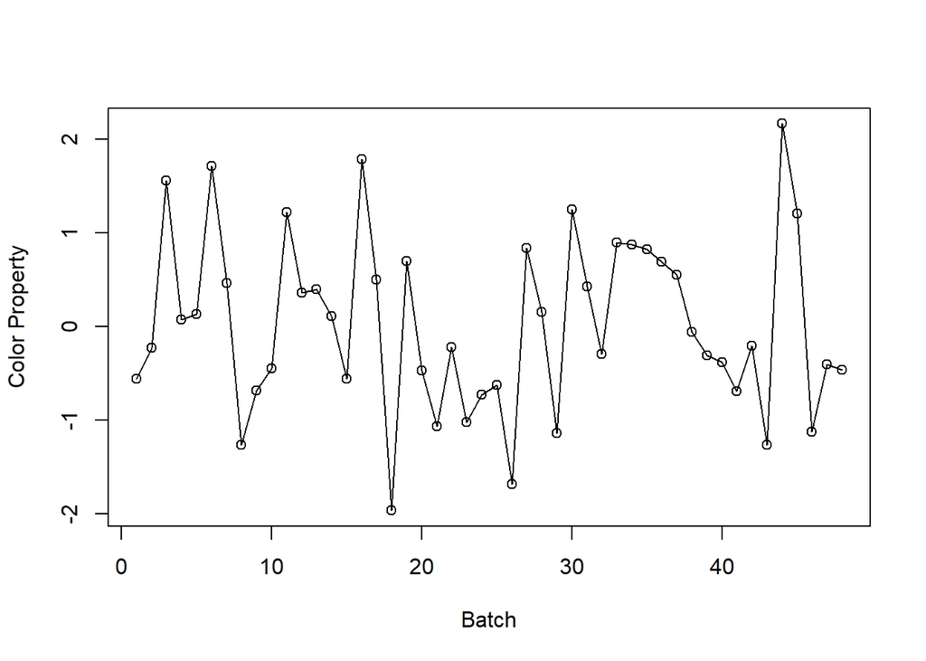

```r
# Set seed for reproducibility
set.seed(123)

# Generate a random process of length 48 with independent normal values
random_process <- rnorm(48)

data = data.frame(index = c(1:48),random_process)

plot(data,ylab='Color Property',xlab='Batch',type='o')
```

#### 1.4 Simulate a completely random process of length 48 with independent, chi-square distributed values, each with 2 degrees of freedom. Display the time series plot. Does it look “random” and nonnormal? Repeat this exercise several times with a new simulation each time.

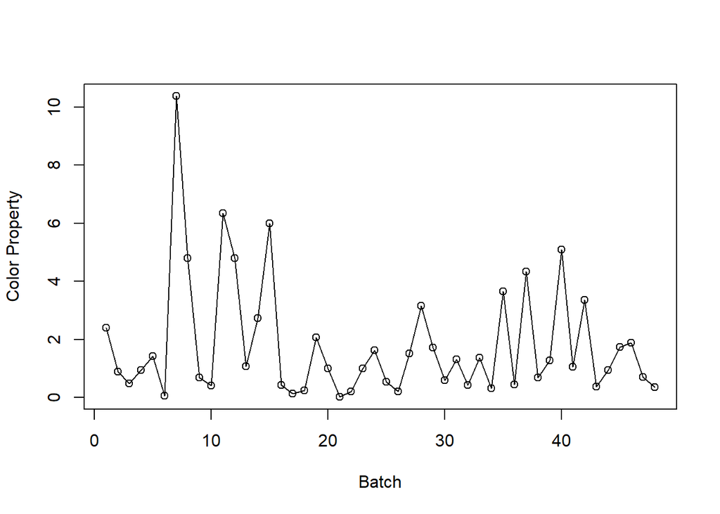

```r
# Generate a random process of length 48 with independent normal values
random_process_chisq <- rchisq(48, df = 2)

data = data.frame(index = c(1:48),random_process_chisq)

plot(data,ylab='Color Property',xlab='Batch',type='o')
```

#### 1.5 Simulate a completely random process of length 48 with independent, t-distributed values each with 5 degrees of freedom. Construct the time series plot. Does it look “random” and nonnormal? Repeat this exercise several times with a new simulation each time.

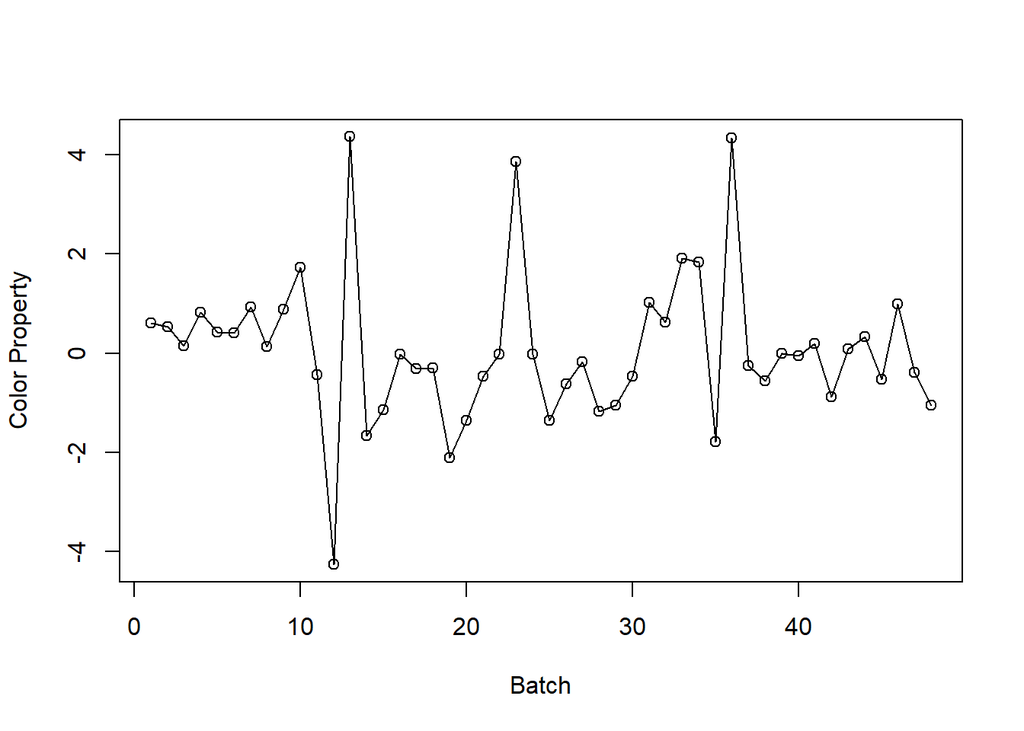

```r
# Generate a random process of length 48 with independent normal values
random_process_t <- rt(48, df = 5)

data = data.frame(index = c(1:48),random_process_t)

plot(data,ylab='Color Property',xlab='Batch',type='o')
```

#### 1.6 Construct a time series plot with monthly plotting symbols for the Dubuque temperature series as in Exhibit 1.9, on page 7. The data are in the file named `tempdub`.